# **The Covid - 19 Pandemic in Egypt**

V.D.D.Roshani

2022-10-01

# 1. Introduction

### 1.1 Geography of Egypt

Egypt has coastlines on the Mediterranean Sea, the River Nile, and the Red Sea. Egypt borders Libya to the west, the Gaza Strip to the northeast, Israel to the east and Sudan to the south. Egypt has an area of 1,002,450 km2 (387,050 sq mi) which makes it the 29th largest country in the world.

The longest straight-line distance in Egypt from north to south is 1,420 km (880 mi), while that from east to west measures 1,275 km (792 mi). Egypt has more than 2,900 km (1,800 mi) of coastline on the Mediterranean Sea, the Gulf of Suez, and the Gulf of Aqaba. It has an Exclusive Economic Zone of 263,451 km2 (101,719 sq mi).

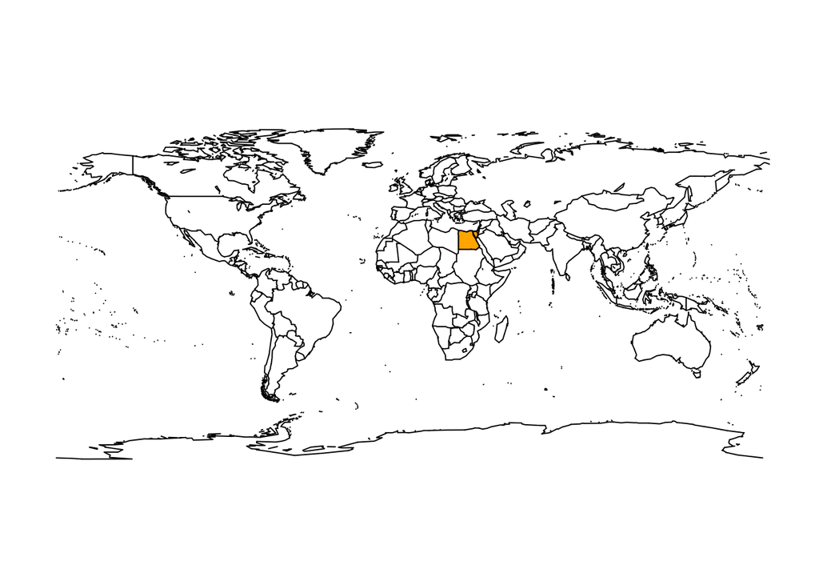

### 1.2 Population of Egypt

Egypt has a population of about 102 million people. According to current projections, Egypt’s population is expected to double by 2078. The population is currently growing at a rate of 1.94%, a rate that adds about 2 million people to the population every year.

Egypt’s fertility rate is about 3.3 births per woman, well above the population replacement rate of 2.1 births per woman. Egypt has a relatively young population, where about 60% of the population is under 30 years old.

The rapidly increasing population poses a threat to the Egyptian economy, where one-third of people live below the poverty line and the unemployment rate is around 10%.

### 1.3 Impact of Covid-19

The first case of COVID-19 in Egypt was confirmed on February 14th, 2020 (IMF, 2021a). On March 24th, the government declared a public health emergency followed by a nationwide lock down aiming to contain the spread of the virus. Among the lock down measures, the government implemented a two-week curfew (Beschel, 2021), which was later extended to a month (Reuters, 2020).2 The curfew applied from 7 PM to 6 AM, during which time all public and private transport was suspended. All educational institutions were shut down until further notice. Shops and malls were closed on weekends and restaurants and coffee shops were only open for home delivery. Public events such as government meetings and sports events were restricted, a stay-at-home order was imposed with exceptions for essential trips, restrictions on internal movements were imposed, and a total border closure was instituted (Beschel, 2021). Most businesses remained open, but some of them may have reduced their hours to conform to the curfew. During the initial two weeks of lock down the government also suspended work on mega projects which led to a substantial decline in workforce on construction sites.

# 2.Explanatory Data Analysis about Covid- 19 Cases

For this analysis I used the **coronavirus** data set and the data set has been filtered into **egypt_corona** - corona virus data of Egypt.Further there is a daily summary of corona virus(COVID - 19)cases by state/province of each country in **coronavirus** data set.There are 742,560 observations in this **coronavirus** data set with 15 variables.

Variables

- **date** - Date in YYYY-MM-DD format.
- **province** - Name of province/state, for countries where data is provided split across multiple provinces/states.
- **country** - Name of country/region.
- **lat** - Latitude of center of geographic region, defined as either country or, if available, province.
- **long** - Longitude of center of geographic region, defined as either country or, if available, province.
- **type** - An indicator for the type of cases (confirmed, death, recovered).
- **cases** - Number of cases on given date.
- **uid** - Country code
- **iso2** - Officially assigned country code identifiers with two-letter
- **iso3** - Officially assigned country code identifiers with three-letter
- **code3** - UN country code
- **combined_key** - Country and province (if applicable)
- **population** - Country or province population
- **continent_name** - Continent name
- **continent_code** - Continent code

```r
str(coronavirus) # internal data structure of the coronavirus data set
```

```
## 'data.frame':    742560 obs. of  15 variables:
##  $ date          : Date, format: "2020-01-22" "2020-01-23" ...
##  $ province      : chr  "Alberta" "Alberta" "Alberta" "Alberta" ...
##  $ country       : chr  "Canada" "Canada" "Canada" "Canada" ...
##  $ lat           : num  53.9 53.9 53.9 53.9 53.9 ...
##  $ long          : num  -117 -117 -117 -117 -117 ...
##  $ type          : chr  "confirmed" "confirmed" "confirmed" "confirmed" ...
##  $ cases         : int  0 0 0 0 0 0 0 0 0 0 ...
##  $ uid           : num  12401 12401 12401 12401 12401 ...
##  $ iso2          : chr  "CA" "CA" "CA" "CA" ...
##  $ iso3          : chr  "CAN" "CAN" "CAN" "CAN" ...
##  $ code3         : num  124 124 124 124 124 124 124 124 124 124 ...
##  $ combined_key  : chr  "Alberta, Canada" "Alberta, Canada" "Alberta, Canada" "Alberta, Canada" ...
##  $ population    : num  4413146 4413146 4413146 4413146 4413146 ...
##  $ continent_name: chr  "North America" "North America" "North America" "North America" ...
##  $ continent_code: chr  "NA" "NA" "NA" "NA" ...
```

From above data set we take 2652 observations with 15 variables related to Egypt for analysis.In below, there is a internal structure of *egypt_corona* data set and first few data.The data set contains the daily summary of Corona virus cases (confirmed, death, and recovered), by state/province of Egypt.

```
## 'data.frame':    2652 obs. of  15 variables:
##  $ date          : Date, format: "2020-01-22" "2020-01-23" ...
##  $ province      : chr  NA NA NA NA ...
##  $ country       : chr  "Egypt" "Egypt" "Egypt" "Egypt" ...
##  $ lat           : num  26.8 26.8 26.8 26.8 26.8 ...
##  $ long          : num  30.8 30.8 30.8 30.8 30.8 ...
##  $ type          : chr  "confirmed" "confirmed" "confirmed" "confirmed" ...
##  $ cases         : int  0 0 0 0 0 0 0 0 0 0 ...
##  $ uid           : num  818 818 818 818 818 818 818 818 818 818 ...
##  $ iso2          : chr  "EG" "EG" "EG" "EG" ...
##  $ iso3          : chr  "EGY" "EGY" "EGY" "EGY" ...
##  $ code3         : num  818 818 818 818 818 818 818 818 818 818 ...
##  $ combined_key  : chr  "Egypt" "Egypt" "Egypt" "Egypt" ...
##  $ population    : num  1.02e+08 1.02e+08 1.02e+08 1.02e+08 1.02e+08 ...
##  $ continent_name: chr  "Africa" "Africa" "Africa" "Africa" ...
##  $ continent_code: chr  "AF" "AF" "AF" "AF" ...
```

```
##         date province country      lat    long      type cases uid iso2 iso3
## 1 2020-01-22     <NA>   Egypt 26.82055 30.8025 confirmed     0 818   EG  EGY
## 2 2020-01-23     <NA>   Egypt 26.82055 30.8025 confirmed     0 818   EG  EGY
## 3 2020-01-24     <NA>   Egypt 26.82055 30.8025 confirmed     0 818   EG  EGY
## 4 2020-01-25     <NA>   Egypt 26.82055 30.8025 confirmed     0 818   EG  EGY
## 5 2020-01-26     <NA>   Egypt 26.82055 30.8025 confirmed     0 818   EG  EGY
## 6 2020-01-27     <NA>   Egypt 26.82055 30.8025 confirmed     0 818   EG  EGY
##   code3 combined_key population continent_name continent_code
## 1   818        Egypt  102334403         Africa             AF
## 2   818        Egypt  102334403         Africa             AF
## 3   818        Egypt  102334403         Africa             AF
## 4   818        Egypt  102334403         Africa             AF
## 5   818        Egypt  102334403         Africa             AF
## 6   818        Egypt  102334403         Africa             AF
```

```
##         date province country      lat    long     type cases uid iso2 iso3
## 1 2020-01-22     <NA>   Egypt 26.82055 30.8025 recovery     0 818   EG  EGY
## 2 2020-01-23     <NA>   Egypt 26.82055 30.8025 recovery     0 818   EG  EGY
## 3 2020-01-24     <NA>   Egypt 26.82055 30.8025 recovery     0 818   EG  EGY
## 4 2020-01-25     <NA>   Egypt 26.82055 30.8025 recovery     0 818   EG  EGY
## 5 2020-01-26     <NA>   Egypt 26.82055 30.8025 recovery     0 818   EG  EGY
## 6 2020-01-27     <NA>   Egypt 26.82055 30.8025 recovery     0 818   EG  EGY
##   code3 combined_key population continent_name continent_code
## 1   818        Egypt  102334403         Africa             AF
## 2   818        Egypt  102334403         Africa             AF
## 3   818        Egypt  102334403         Africa             AF
## 4   818        Egypt  102334403         Africa             AF
## 5   818        Egypt  102334403         Africa             AF
## 6   818        Egypt  102334403         Africa             AF
```

```
##         date province country      lat    long  type cases uid iso2 iso3 code3
## 1 2020-01-22     <NA>   Egypt 26.82055 30.8025 death     0 818   EG  EGY   818
## 2 2020-01-23     <NA>   Egypt 26.82055 30.8025 death     0 818   EG  EGY   818
## 3 2020-01-24     <NA>   Egypt 26.82055 30.8025 death     0 818   EG  EGY   818
## 4 2020-01-25     <NA>   Egypt 26.82055 30.8025 death     0 818   EG  EGY   818
## 5 2020-01-26     <NA>   Egypt 26.82055 30.8025 death     0 818   EG  EGY   818
## 6 2020-01-27     <NA>   Egypt 26.82055 30.8025 death     0 818   EG  EGY   818
##   combined_key population continent_name continent_code
## 1        Egypt  102334403         Africa             AF
## 2        Egypt  102334403         Africa             AF
## 3        Egypt  102334403         Africa             AF
## 4        Egypt  102334403         Africa             AF
## 5        Egypt  102334403         Africa             AF
## 6        Egypt  102334403         Africa             AF
```

In below table number of Corona cases are classified into confirmed, recovered and death.

```
##   Case_type No_of_Cases
## 1 Confirmed      515645
## 2     Death       24722
## 3 Recovered      232185
```

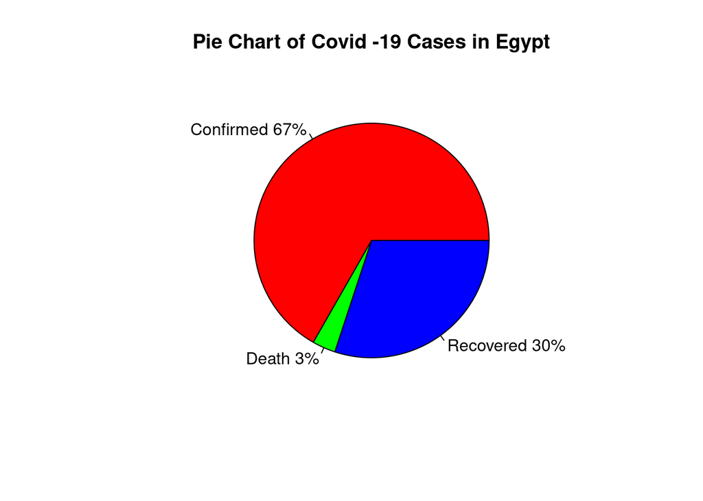

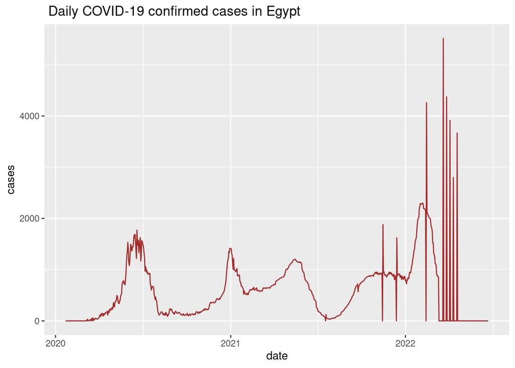

This figure shows that the how the confirmed covid 19 cases fluctuated from beginning to the end.

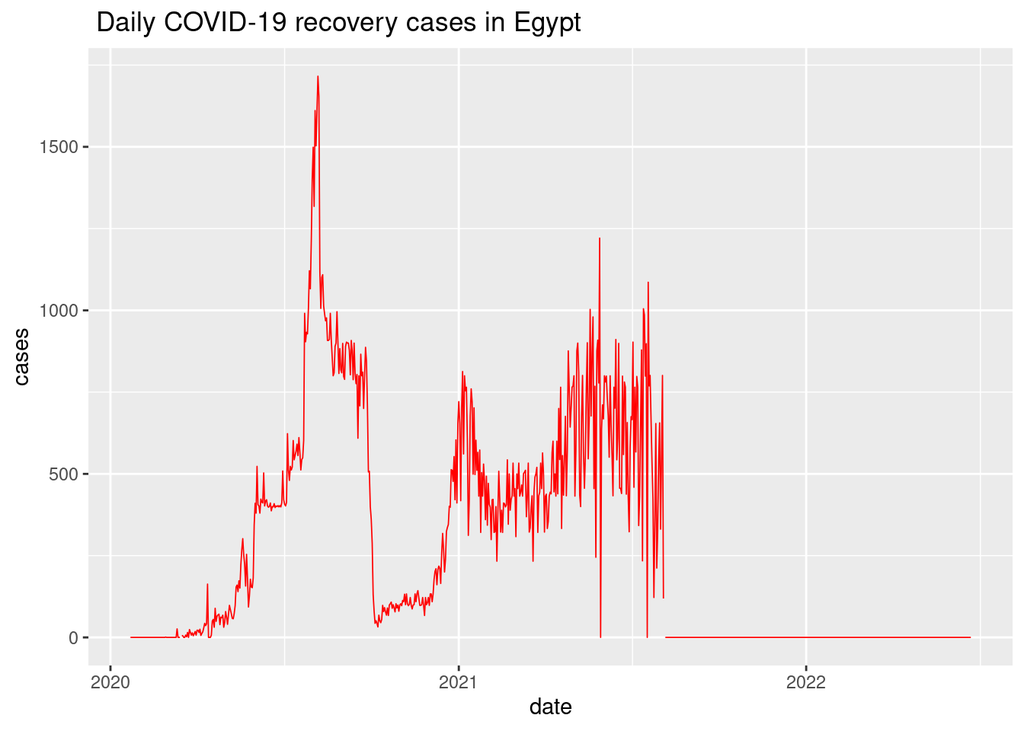

Above graph shows that recovery cases fluctuation from beginning to end.

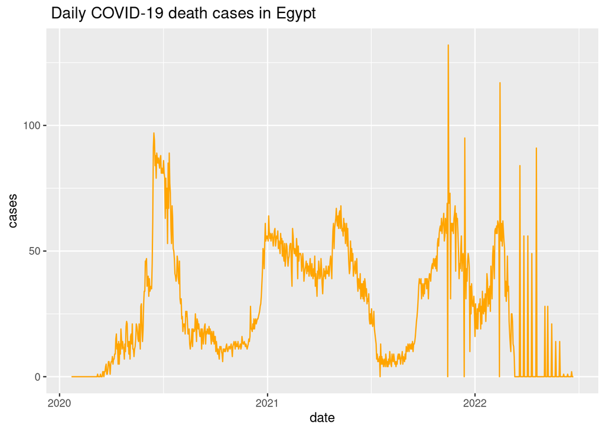

Above graph shows that death cases fluctuation from beginning to end.

All the covid cases can be shown in one graph as below.

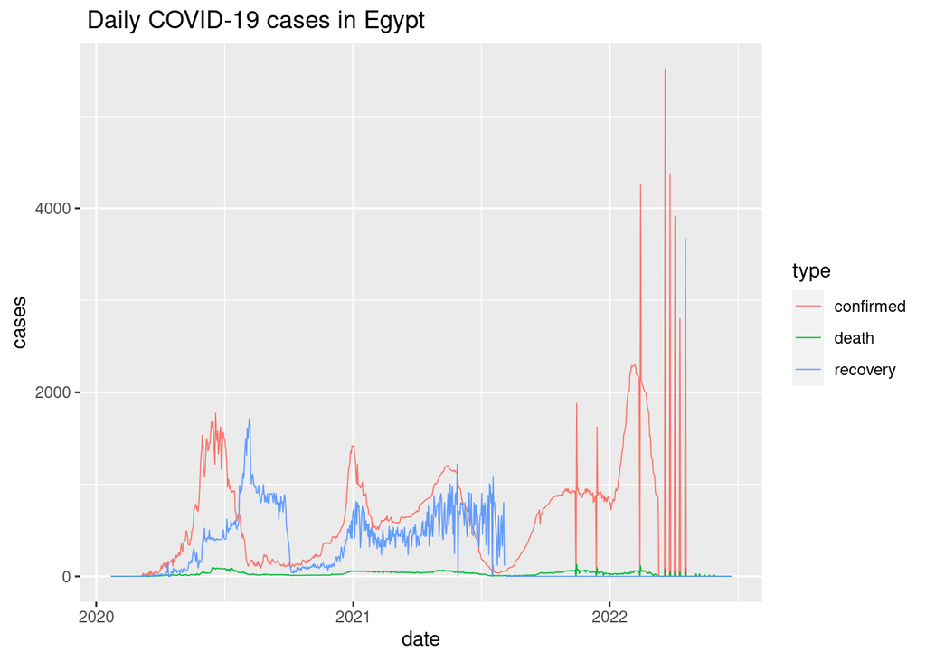

```r
egypt_corona1 <-data.frame(egypt_corona)
egypt_corona1[egypt_corona1<0] <-NA
(ggplot(egypt_corona1, aes(x = date, y= cases,col=type))
     + geom_line(size = 0.3)
      +ggtitle(" Daily COVID-19 cases in Egypt"))
```

##### Summary Covid data table of Egypt

```
## tibble [3 × 5] (S3: tbl_df/tbl/data.frame)
##  $ type   : chr [1:3] "confirmed" "death" "recovery"
##  $ minimum: int [1:3] 0 0 NA
##  $ maximum: int [1:3] 5516 132 NA
##  $ median : num [1:3] 496 22 NA
##  $ mean   : num [1:3] 583 28 NA
```

### 3. Neighbourhood Countries

We can recognized Libya, Sudan, Israel as the neighborhood countries to the Egypt.

```
## 'data.frame':    2652 obs. of  15 variables:
##  $ date          : Date, format: "2020-01-22" "2020-01-23" ...
##  $ province      : chr  NA NA NA NA ...
##  $ country       : chr  "Libya" "Libya" "Libya" "Libya" ...
##  $ lat           : num  26.3 26.3 26.3 26.3 26.3 ...
##  $ long          : num  17.2 17.2 17.2 17.2 17.2 ...
##  $ type          : chr  "confirmed" "confirmed" "confirmed" "confirmed" ...
##  $ cases         : int  0 0 0 0 0 0 0 0 0 0 ...
##  $ uid           : num  434 434 434 434 434 434 434 434 434 434 ...
##  $ iso2          : chr  "LY" "LY" "LY" "LY" ...
##  $ iso3          : chr  "LBY" "LBY" "LBY" "LBY" ...
##  $ code3         : num  434 434 434 434 434 434 434 434 434 434 ...
##  $ combined_key  : chr  "Libya" "Libya" "Libya" "Libya" ...
##  $ population    : num  6871287 6871287 6871287 6871287 6871287 ...
##  $ continent_name: chr  "Africa" "Africa" "Africa" "Africa" ...
##  $ continent_code: chr  "AF" "AF" "AF" "AF" ...
```

```
## 'data.frame':    2652 obs. of  15 variables:
##  $ date          : Date, format: "2020-01-22" "2020-01-23" ...
##  $ province      : chr  NA NA NA NA ...
##  $ country       : chr  "Sudan" "Sudan" "Sudan" "Sudan" ...
##  $ lat           : num  12.9 12.9 12.9 12.9 12.9 ...
##  $ long          : num  30.2 30.2 30.2 30.2 30.2 ...
##  $ type          : chr  "confirmed" "confirmed" "confirmed" "confirmed" ...
##  $ cases         : int  0 0 0 0 0 0 0 0 0 0 ...
##  $ uid           : num  729 729 729 729 729 729 729 729 729 729 ...
##  $ iso2          : chr  "SD" "SD" "SD" "SD" ...
##  $ iso3          : chr  "SDN" "SDN" "SDN" "SDN" ...
##  $ code3         : num  729 729 729 729 729 729 729 729 729 729 ...
##  $ combined_key  : chr  "Sudan" "Sudan" "Sudan" "Sudan" ...
##  $ population    : num  43849269 43849269 43849269 43849269 43849269 ...
##  $ continent_name: chr  "Africa" "Africa" "Africa" "Africa" ...
##  $ continent_code: chr  "AF" "AF" "AF" "AF" ...
```

```
## 'data.frame':    2652 obs. of  15 variables:
##  $ date          : Date, format: "2020-01-22" "2020-01-23" ...
##  $ province      : chr  NA NA NA NA ...
##  $ country       : chr  "Israel" "Israel" "Israel" "Israel" ...
##  $ lat           : num  31 31 31 31 31 ...
##  $ long          : num  34.9 34.9 34.9 34.9 34.9 ...
##  $ type          : chr  "confirmed" "confirmed" "confirmed" "confirmed" ...
##  $ cases         : int  0 0 0 0 0 0 0 0 0 0 ...
##  $ uid           : num  376 376 376 376 376 376 376 376 376 376 ...
##  $ iso2          : chr  "IL" "IL" "IL" "IL" ...
##  $ iso3          : chr  "ISR" "ISR" "ISR" "ISR" ...
##  $ code3         : num  376 376 376 376 376 376 376 376 376 376 ...
##  $ combined_key  : chr  "Israel" "Israel" "Israel" "Israel" ...
##  $ population    : num  8655541 8655541 8655541 8655541 8655541 ...
##  $ continent_name: chr  "Asia" "Asia" "Asia" "Asia" ...
##  $ continent_code: chr  "AS" "AS" "AS" "AS" ...
```

### References

https://www.nationsonline.org/oneworld/map/egypt_map.htm#:~:text=Countries%20with%20international%20borders%20to,%2C%20Saudi%20Arabia%2C%20and%20Turkey.

https://www.unwomen.org/en/digital-library/publications/2022/06/government-responses-to-covid-19-lessons-on-gender-equality-for-a-world-in-turmoil?gclid=CjwKCAjwv4SaBhBPEiwA9YzZvMD46YmTIq3I0HO-NdxaHHDBt9LJ0p6_eLImcGUR_RoDDqBCu5N0RBoCDOQQAvD_BwE

https://statisticsglobe.com/graphics-in-r